# Analyse dimensionnelle à l’aide d’une matrice totale des corrélations

```r
pacman::p_load(TAM, psych, tidyverse, data.table)
```

Nous présentons ici la situation où la matrice person-item est suffisamment pleine pour que nous récupérions l’ensemble des coefficients de corrélation polychoriques.

Nous prendrons comme exemple la table *data.fims.Aus.Jpn.scored* présente dans le package *TAM*

```r
data("data.fims.Aus.Jpn.scored", package = "TAM")
DATA = data.fims.Aus.Jpn.scored %>% select(starts_with("M1"))
DATA %>% psych::describe()
```

|  | vars | n | mean | sd | median | trimmed | mad | min | max | range | skew | kurtosis | se |
| --- | --- | --- | --- | --- | --- | --- | --- | --- | --- | --- | --- | --- | --- |
| M1PTI1 | 1 | 6371 | 0.77 | 0.42 | 1 | 0.84 | 0 | 0 | 1 | 1 | -1.30 | -0.30 | 0.01 |
| M1PTI2 | 2 | 6371 | 0.76 | 0.43 | 1 | 0.83 | 0 | 0 | 1 | 1 | -1.23 | -0.49 | 0.01 |
| M1PTI3 | 3 | 6371 | 0.85 | 0.36 | 1 | 0.93 | 0 | 0 | 1 | 1 | -1.92 | 1.69 | 0.00 |
| M1PTI6 | 4 | 6371 | 0.57 | 0.49 | 1 | 0.59 | 0 | 0 | 1 | 1 | -0.29 | -1.92 | 0.01 |
| M1PTI7 | 5 | 6371 | 0.16 | 0.37 | 0 | 0.08 | 0 | 0 | 1 | 1 | 1.82 | 1.33 | 0.00 |
| M1PTI11 | 6 | 6371 | 0.80 | 0.40 | 1 | 0.87 | 0 | 0 | 1 | 1 | -1.47 | 0.16 | 0.01 |
| M1PTI12 | 7 | 6371 | 0.34 | 0.47 | 0 | 0.30 | 0 | 0 | 1 | 1 | 0.67 | -1.56 | 0.01 |
| M1PTI14 | 8 | 6371 | 0.40 | 0.49 | 0 | 0.37 | 0 | 0 | 1 | 1 | 0.41 | -1.83 | 0.01 |
| M1PTI17 | 9 | 6371 | 0.26 | 0.44 | 0 | 0.20 | 0 | 0 | 1 | 1 | 1.10 | -0.79 | 0.01 |
| M1PTI18 | 10 | 6371 | 0.61 | 0.49 | 1 | 0.64 | 0 | 0 | 1 | 1 | -0.46 | -1.79 | 0.01 |

[output cut: 4 more lines]

Nous calculons donc les coefficients polychoriques

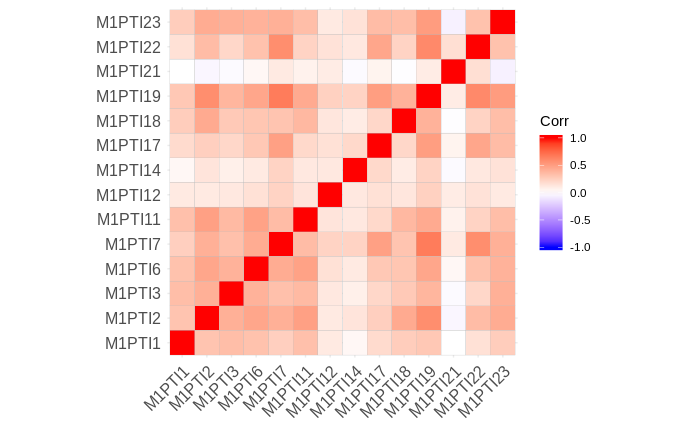

```r
TET = DATA %>% psych::polychoric()

TET$rho %>% ggcorrplot::ggcorrplot()
```

On peut s’attendre à un souci avec les items **M1PTI12**, **M1PTI14** et **M1PTI21**

# Anayse factorielle exploratoire

la fonction *fa.parallel* réalise une estimation (souvent grossière) des facteurs d’intérêt.

```
Parallel analysis suggests that the number of factors =  5  and the number of components =  NA
```

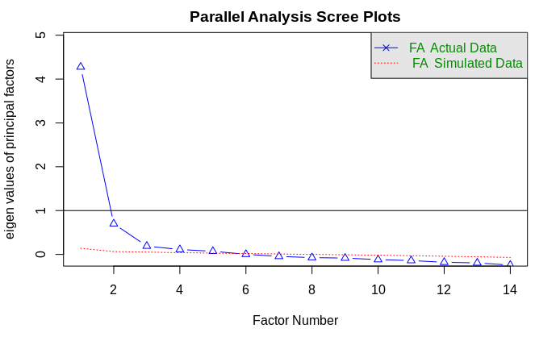

```r
TET$rho %>% fa.parallel(n.obs = nrow(DATA), fa = "fa")
```

Ici, le test du coude nous inspirerait plutôt 2 facteurs.

```r
FA = TET$rho %>% psych::fa(nfactors = 2,
                           n.obs = nrow(DATA))
```

Quelle est la part de variance expliquée par ces 2 facteurs?

```r
FA$Structure
```

```
Loadings:
        MR2    MR1
M1PTI1   0.486  0.276
M1PTI2   0.726  0.498
M1PTI3   0.594  0.359
M1PTI6   0.651  0.482
M1PTI7   0.561  0.796
M1PTI11  0.653  0.400
M1PTI12  0.196  0.270
M1PTI14  0.175  0.261
M1PTI17  0.377  0.620
M1PTI18  0.540  0.368
M1PTI19  0.699  0.835
M1PTI21         0.152
M1PTI22  0.403  0.726
M1PTI23  0.604  0.496

                 MR2   MR1
SS loadings    3.798 3.634
Proportion Var 0.271 0.260
Cumulative Var 0.271 0.531
```

Plus de 50%. C’est satisfaisant.  
Quelle est la structure des loadings?

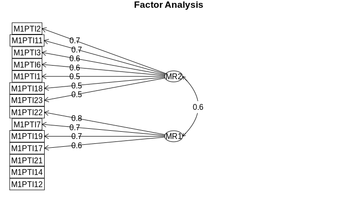

```r
FA %>% fa.diagram(cut = .3, sort = T)
```

# Analyse confirmatoire: les coefficients *omega*

L’idée derrière le coefficient *omega* est de découper la variance entre une variance d’ordre supérieure (générale) et des variances résiduelles pour chacun des facteurs.

```r
OMEGA =
  TET$rho %>% psych::omega(
    nfactors = 2,
    n.obs = nrow(DATA),
    fm = "ml",
    plot = F
  )
```

```
Three factors are required for identification -- general factor loadings set to be equal.
Proceed with caution.
Think about redoing the analysis with alternative values of the 'option' setting.
```

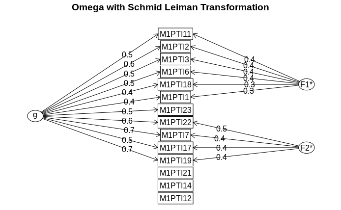

```r
OMEGA%>% omega.diagram(cut = .3, gcut = .3, sort = T)
```

Si le facteur g est signifiant, alors on peut espérer pouvoir réduire le modèle à une seule dimension.

```r
OMEGA %>% summary()
```

```
Omega
Alpha:                 0.83
G.6:                   0.85
Omega Hierarchical:    0.67
Omega H asymptotic:    0.78
Omega Total            0.86

With eigenvalues of:
   g  F1*  F2*
3.38 0.94 0.82
The degrees of freedom for the model is 64  and the fit was  0.2
The number of observations was  6371  with Chi Square =  1267.29  with prob <  0

The root mean square of the residuals is  0.03
The df corrected root mean square of the residuals is  0.04

RMSEA and the  0.9 confidence intervals are  0.054 0.052 0.057
BIC =  706.68Explained Common Variance of the general factor =  0.66

 Total, General and Subset omega for each subset
                                                 g  F1*  F2*
Omega total for total scores and subscales    0.86 0.80 0.74
Omega general for total scores and subscales  0.67 0.53 0.49
Omega group for total scores and subscales    0.17 0.27 0.26
```

*ECV* (Explained Common Variance) est la part de variance expliquée par le facteur général, rapportée à la variance totale **expliquée**. elle doit être supérieure à 0.5 pour que l’utilisation des coefficients *omega* soit pertinente.

*Omega Total* représente l’ensemble de la variance expliquée par le modèle. Elle doit être proche de 1.

*Omega Hierarchical* représente la part de variance expliquée par le facteur général. Si elle est voisine de *Omega Total*, alors l’hypothèse d’unidimensionnalité est pertinente.

```r
OMEGA$omega.group %>% rownames_to_column(var = "Dim") %>%
  group_by(Dim) %>% transmute(Part_general = general / total,
                              Part_groupe = group / total) %>%
  data.table()
```

| Dim | Part_general | Part_groupe |
| --- | --- | --- |
| g | 0.7780508 | 0.2029559 |
| F1* | 0.6633049 | 0.3366951 |
| F2* | 0.6521328 | 0.3478672 |

## Réduction du périmètre

On réduit le périmètre aux items intéressants.

```r
Items_EFA =
  FA$loadings %>% unclass %>% as_tibble(rownames = NA) %>% rownames_to_column(var = "item") %>%
  gather(key = Dim, value = Loading, -item) %>%
  filter(abs(Loading)>.3) %>% distinct(item) %>% droplevels()

TET_EFA = DATA %>% select(Items_EFA$item) %>% psych::polychoric()
```

et on reproduit l’analyse confirmatoire.

```r
OMEGA =
  TET_EFA$rho %>% psych::omega(
    nfactors = 2,
    n.obs = nrow(DATA),
    fm = "ml",
    plot = F
  )
```

```
Three factors are required for identification -- general factor loadings set to be equal.
Proceed with caution.
Think about redoing the analysis with alternative values of the 'option' setting.
```

```r
OMEGA %>% summary()
```

```
Omega
Alpha:                 0.86
G.6:                   0.87
Omega Hierarchical:    0.68
Omega H asymptotic:    0.77
Omega Total            0.88

With eigenvalues of:
   g  F1*  F2*
3.26 0.93 0.77
The degrees of freedom for the model is 34  and the fit was  0.11
The number of observations was  6371  with Chi Square =  697.43  with prob <  0

The root mean square of the residuals is  0.03
The df corrected root mean square of the residuals is  0.04

RMSEA and the  0.9 confidence intervals are  0.055 0.052 0.059
BIC =  399.6Explained Common Variance of the general factor =  0.66

 Total, General and Subset omega for each subset
                                                 g  F1*  F2*
Omega total for total scores and subscales    0.88 0.80 0.84
Omega general for total scores and subscales  0.68 0.53 0.56
Omega group for total scores and subscales    0.18 0.27 0.28
```

```r
OMEGA$omega.group %>% rownames_to_column(var = "Dim") %>%
  group_by(Dim) %>% transmute(general / total, group / total)
```

| Dim | general/total | group/total |
| --- | --- | --- |
| g | 0.7691197 | 0.1999097 |
| F1* | 0.6623324 | 0.3376676 |
| F2* | 0.6692886 | 0.3307114 |

Rajoutons qu’on peut décrire ces modèles sous leur forme bifactorielle :

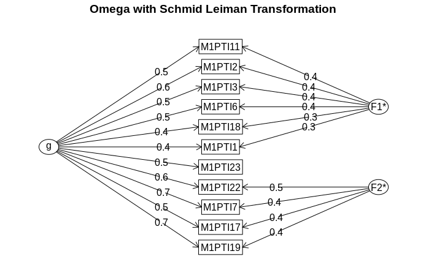

```r
OMEGA%>% omega.diagram(cut = .3, gcut = .3, sort = T)
```

ou sous leur forme hiérarchique, avec le facteur générale étant une combinaison des facteurs sous-jacents:

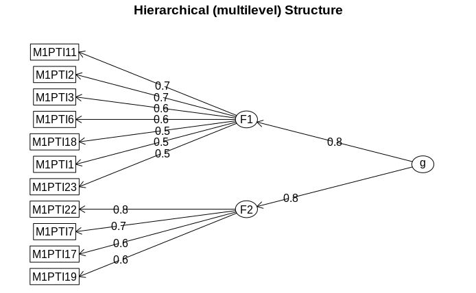

```r
OMEGA%>% omega.diagram(cut = .3, gcut = .3, sl = F)
```

# le *beta* de Revelle

Pour information, il existe aussi une méthode complète de construction des sous-échelles.

Il s’agit de regrouper de manière ascendante les items par cohérence interne, et de calculer l’*alpha* de Cronbach à chaque étape.  
Les regroupements perdent de leur sens quand *alpha* se met à décroître.

```
ICLUST (Item Cluster Analysis)
Call: psych::iclust(r.mat = .)

Purified Alpha:
[1] 0.83

G6* reliability:
[1] 1

Original Beta:
[1] 0.29

Cluster size:
[1] 14

Item by Cluster Structure matrix:
        [,1]
M1PTI1  0.42
M1PTI2  0.66
M1PTI3  0.53
M1PTI6  0.63
M1PTI7  0.74
M1PTI11 0.59
M1PTI12 0.27
M1PTI14 0.24
M1PTI17 0.54
M1PTI18 0.50
M1PTI19 0.83
M1PTI21 0.08
M1PTI22 0.60
M1PTI23 0.60

With eigenvalues of:
[1] 4.3

Purified scale intercorrelations
 reliabilities on diagonal
 correlations corrected for attenuation above diagonal:
     [,1]
[1,] 0.83

Cluster fit =  0.75   Pattern fit =  0.98  RMSR =  0.06
```

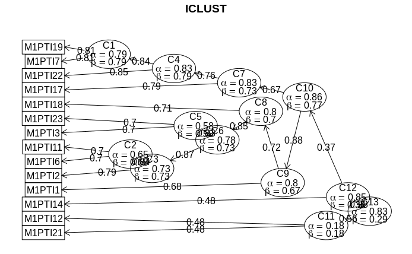

```r
TET$rho %>% psych::iclust()
```

On retrouve nos 3 items à exclure.

```
ICLUST (Item Cluster Analysis)
Call: psych::iclust(r.mat = .)

Purified Alpha:
[1] 0.86

G6* reliability:
[1] 1

Original Beta:
[1] 0.77

Cluster size:
[1] 11

Item by Cluster Structure matrix:
        [,1]
M1PTI1  0.44
M1PTI2  0.69
M1PTI3  0.54
M1PTI6  0.64
M1PTI11 0.59
M1PTI18 0.51
M1PTI23 0.62
M1PTI7  0.71
M1PTI17 0.52
M1PTI19 0.82
M1PTI22 0.58

With eigenvalues of:
[1] 4.2

Purified scale intercorrelations
 reliabilities on diagonal
 correlations corrected for attenuation above diagonal:
     [,1]
[1,] 0.86

Cluster fit =  0.82   Pattern fit =  0.98  RMSR =  0.07
```

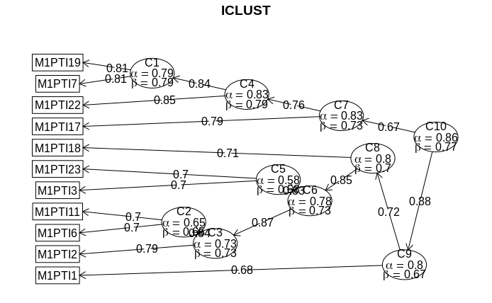

```r
TET_EFA$rho %>% psych::iclust()
```

Avec un seuil à 0.8 pour *alpha*, on retrouve notre dimension unique, et un ensemble de sous-échelles, dont nos 2 sous-dimensions.